# 01_data-cleaning

### Save

I’ll save the cleaned dataset with a new name `clean_data` which can be loaded directly in other analysis files

```r
clean_data <- raw_data
save(clean_data, file = here("assets/clean_data/clean_data.rds"))
rm(clean_data)
```

## Shapefile

Quick look at the shapefile to make sure everything is in order

```r
glimpse(shapefile)
```

```
## Observations: 13
## Variables: 7
## $ PRUID    <chr> "59", "24", "62", "11", "47", "60", "46", "35", "13",...
## $ PRNAME   <chr> "British Columbia / Colombie-Britannique", "Quebec / ...
## $ PRENAME  <chr> "British Columbia", "Quebec", "Nunavut", "Prince Edwa...
## $ PRFNAME  <chr> "Colombie-Britannique", "Qu\xe9bec", "Nunavut", "\xce...
## $ PREABBR  <chr> "B.C.", "Que.", "Nvt.", "P.E.I.", "Sask.", "Y.T.", "M...
## $ PRFABBR  <chr> "C.-B.", "Qc", "Nt", "\xce.-P.-\xc9.", "Sask.", "Yn",...
## $ geometry <MULTIPOLYGON [Â°]> MULTIPOLYGON (((-124 48.3, ..., MULTIPO...
```

Need to change one variable name and drop some unneeded variables

```r
shapefile %<>%
  rename(province = PRENAME) %>%
  select(province, geometry)
```

And a quick plot of the blank file to check it looks ok

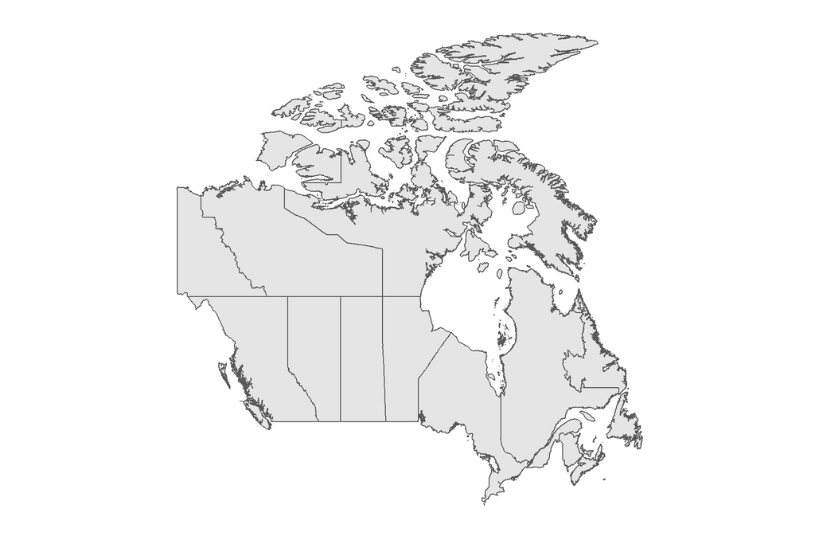

```r
shapefile %>%
  ggplot() +
  geom_sf() +
  theme(line = element_blank(),
        axis.text = element_blank(),
        panel.grid = element_line(colour = "transparent"))
```

### Save it

```r
save(shapefile, file = here("assets/clean_data/shapefile.rds"))
```

## Population

May or may not do this - think the data is a survey sample so won’t be able to calculate rates.